# 2_Sessia

Скачиваем библиотеки

```python
!pip install lxml
!pip install lightgbm
!pip install phik
!pip install pandas
!pip install numpy
!pip install seaborn
!pip install matplotlib
!pip install sklearn
!pip install phik
!pip install random
!pip install -U scikit-learn
```

[output not shown]

```python
import requests
import lxml
from bs4 import BeautifulSoup
import pandas as pd
import numpy as mp
import json
from tqdm.notebook import tqdm
import folium
import seaborn as sns
import matplotlib.pyplot as plt
import missingno as msno
import numpy as np
from sklearn.cluster import KMeans, DBSCAN
from sklearn.mixture import GaussianMixture
from sklearn.preprocessing import LabelEncoder, StandardScaler

from phik.report import plot_correlation_matrix
# from sklearn.pipeline import Pipeline

from lightgbm import LGBMClassifier
from sklearn.linear_model import LogisticRegression
from sklearn.ensemble import RandomForestClassifier
from random import randint
from sklearn.model_selection import train_test_split, KFold, cross_val_score, RandomizedSearchCV, GridSearchCV
from sklearn.metrics import roc_auc_score, accuracy_score
```

Загружаем данные

```python
data = pd.read_csv("total_data_lat.csv")
```

# Формирование дополнительных атрибутов

```python
data.head()
```

|  | id | tags | light | nearby | region | address | weather | category | datetime | severity | dead_count | injured_count | parent_region | road_conditions | participants_count | participant_categories | lat | long |
| --- | --- | --- | --- | --- | --- | --- | --- | --- | --- | --- | --- | --- | --- | --- | --- | --- | --- | --- |
| 0 | 2869171 | Дорожно-транспортные происшествия | Светлое время суток | Жилые дома индивидуальной застройки | Барнаул | NO_INFORMATII | Ясно | Наезд на пешехода | 2023-05-24 19:30:00 | Легкий | 0 | 1 | Алтайский край | Сухое | 2 | Все участники, Пешеходы, Мотоциклисты | 53.391200 | 83.787900 |
| 1 | 2320091 | Дорожно-транспортные происшествия, ДТП и постр... | Светлое время суток | Многоквартирные жилые дома, Внутридворовая тер... | Барнаул | г Барнаул, ул Сиреневая, 11 | Пасмурно | Иной вид ДТП | 2015-09-16 13:00:00 | Легкий | 0 | 1 | Алтайский край | Сухое | 2 | Все участники, Дети | 53.345833 | 83.666389 |
| 2 | 2321011 | Дорожно-транспортные происшествия, ДТП и постр... | Светлое время суток | Административные здания, Остановка общественно... | Барнаул | г Барнаул, ул Попова, 165 | Ясно | Падение пассажира | 2017-08-25 15:30:00 | Легкий | 0 | 1 | Алтайский край | Сухое | 3 | Все участники, Дети | 53.197060 | 83.396880 |
| 3 | 2576909 | Дорожно-транспортные происшествия | Светлое время суток | Выезд с прилегающей территории, Административн... | Барнаул | г Барнаул, ул Петра Сухова, 83 А | Ясно | Столкновение | 2021-05-29 19:40:00 | Тяжёлый | 0 | 1 | Алтайский край | Сухое, Отсутствие, плохая различимость горизон... | 3 | Все участники, Мотоциклисты | 53.376400 | 83.714200 |
| 4 | 2575209 | Дорожно-транспортные происшествия | Светлое время суток | Многоквартирные жилые дома, Жилые дома индивид... | Барнаул | г Барнаул, ул Партизанская, 26 | Ясно | Столкновение | 2021-05-25 16:40:00 | Легкий | 0 | 1 | Алтайский край | Сухое, Отсутствие, плохая различимость горизон... | 2 | Все участники | 53.343071 | 83.794366 |

Задаем регионы в переменную uniq_region

```python
uniq_region = data['region'].unique()
uniq_region
```

```
array(['Барнаул', 'Немецкий национальный район', 'Шипуновский район',
       'Чарышский район', 'Целинный район', 'Хабарский район',
       'Усть-Пристанский район', 'Усть-Калманский район',
       'Угловский район', 'Тюменцевский район', 'Троицкий район',
       'Третьсяковский район', 'Топчихинский район', 'Тогульский район',
       'Тальменский район', 'Табунский район', 'Шелаболихинский район',
       'Солтонский район', 'Солонешенский район', 'Советский район',
       'Суетский район', 'Славгородский район', 'Романовский район',
       'Родинский район', 'Ребрихинский район', 'Поспелихинский район',
       'Петропавловский район', 'Панкрушихинский район',
       'Павловский район', 'Зональный район', 'Новичихинский район',
       'Михайловский район', 'Мамонтовский район', 'Локтевский район',
       'Кытмановский район', 'Курьинский район', 'Кулундинский район',
       'Крутихинский район', 'Краснощековский район',
       'Красногорский район', 'Косихинский район', 'Ключевский район',
       'Каменский район', 'Калманский район', 'Змеиногорский район',
       'Залесовский район', 'Завьяловский район', 'Ельцовский район',
       'Егорьевский район', 'Волчихинский район', 'Быстроистокский район',
       'Бурлинский район', 'Благовещенский район', 'Баевский район',
       'Алтайский район', 'Алейский район', 'Смоленский район',
       'Рубцовский район', 'Первомайский район', 'Заринский район',
       'Бийский район', 'Рубцовск', 'Заринск', 'Бийск', 'Белокуриха',
       'Сибирский', 'Новоалтайск', 'Яровое', 'Бурейский район',
       'Свободненский район', 'Серышевский район', 'Белогорский район',
       'Шимановский район', 'Тындинский район', 'Зейский район',
       'Тамбовский район', 'Сковородинский район', 'Селемджинский район',
       'Ромненский район', 'Октябрьский район', 'Мазановский район',
       'Магдагачинский район', 'Константиновский район',
       'Ивановский район', '7 - Завитинский район', 'Архаринский район',
       'пгт. Углегорск', 'Благовещенск', 'Райчихинск', 'Онежский район',
       'Мезенский район', 'Каргопольский район', 'Коношский район',
       'Вельский район', 'Устьянский район', 'Няндомский район',
       'Красноборский район', 'Вилегодский район', 'Ленский район',
       'Холмогорский район', 'Пинежский район', 'Верхнетоемский район',
       'Виноградовский район', 'Шенкурский район', 'Лешуконский район',
       'Новая Земля', 'Приморский район', 'Плесецкий район',
       'Котласский район', 'Новодвинск', 'ЗАТО Мирный', 'Котлас',
       'Архангельск', 'Северодвинск', 'Коряжма', 'Астрахань',
       'Черноярский район', 'Харабалинский район', 'Приволжский район',
       'Наримановский район', 'Лиманский район', 'Красноярский район',
       'Камызякский район', 'Икрянский район', 'Енотовский район',
       'Володарский район', 'Ахтубинский район', 'ЗАТО Знаменск',
       'Белгород', 'Яковлевский район', 'Шебекинский  район',
       'Чернянский район', 'Старооскольский район', 'Ровеньский район',
       'Рекитянский район', 'Прохоровский район', 'Новооскольский район',
       'Краснояружский район', 'Красногвардеский район',
       'Красненский район', 'Корочанский район', 'Ивнянский район',
       'Губкинский район', 'Грайворонский район', 'Волоконовский район',
       'Вейделевский район', 'Валуйский район', 'Борисовский район',
       'Белгородский район', 'Алексеевский район'], dtype=object)
```

Смотрим кол во регионов

```python
len(uniq_region)
```

```
150
```

Создаем функцию для формирования доп атрибутов: danger_level - уровень опасности адреса, который составляется при помощи формулы, использующую сложности ДТП, количество инцидентов по региону и инцедентов по адресу; total_incidents_region - количество инцидентов по региону; total_incidents_address - количество инцидентов по адресу; severity_num - сложность ДТП в цифрах

```python
def total_incidents_on_region(row):
    region = row['region']
    return data[data['region'] == region]['id'].count()

def total_incidents_on_address(row):
    region = row['region']
    address = row['address']
    return data[(data['address'] == address) & (data['region'] == region)]['id'].count()

def severity_to_number(value):
    if value == 'Легкий':
        return 3
    elif value == 'Тяжёлый':
        return 2
    else:
        return 1

def danger_level_value(row):
    severity_num = row['severity_num']
    total_incidents_region = row['total_incidents_region']
    total_incidents_address = row['total_incidents_address']


    danger_level = (2**(abs(severity_num-3)) * (total_incidents_address/total_incidents_region))/total_incidents_region
    return danger_level
```

Используем функцию которую создали раньше

```python
data['total_incidents_region'] = data.apply(total_incidents_on_region, axis=1)
data['total_incidents_address'] = data.apply(total_incidents_on_address, axis=1)
data['severity_num'] = data['severity'].apply(severity_to_number)
data['danger_level'] = data.apply(danger_level_value, axis=1)
data['frequency'] = data['total_incidents_address']/data['total_incidents_region']
data.head()
```

|  | id | tags | light | nearby | region | address | weather | category | datetime | severity | ... | road_conditions | participants_count | participant_categories | lat | long | total_incidents_region | total_incidents_address | severity_num | danger_level | frequency |
| --- | --- | --- | --- | --- | --- | --- | --- | --- | --- | --- | --- | --- | --- | --- | --- | --- | --- | --- | --- | --- | --- |
| 0 | 2869171 | Дорожно-транспортные происшествия | Светлое время суток | Жилые дома индивидуальной застройки | Барнаул | NO_INFORMATII | Ясно | Наезд на пешехода | 2023-05-24 19:30:00 | Легкий | ... | Сухое | 2 | Все участники, Пешеходы, Мотоциклисты | 53.391200 | 83.787900 | 10375 | 563 | 3 | 5.230367e-06 | 0.054265 |
| 1 | 2320091 | Дорожно-транспортные происшествия, ДТП и постр... | Светлое время суток | Многоквартирные жилые дома, Внутридворовая тер... | Барнаул | г Барнаул, ул Сиреневая, 11 | Пасмурно | Иной вид ДТП | 2015-09-16 13:00:00 | Легкий | ... | Сухое | 2 | Все участники, Дети | 53.345833 | 83.666389 | 10375 | 1 | 3 | 9.290173e-09 | 0.000096 |
| 2 | 2321011 | Дорожно-транспортные происшествия, ДТП и постр... | Светлое время суток | Административные здания, Остановка общественно... | Барнаул | г Барнаул, ул Попова, 165 | Ясно | Падение пассажира | 2017-08-25 15:30:00 | Легкий | ... | Сухое | 3 | Все участники, Дети | 53.197060 | 83.396880 | 10375 | 3 | 3 | 2.787052e-08 | 0.000289 |
| 3 | 2576909 | Дорожно-транспортные происшествия | Светлое время суток | Выезд с прилегающей территории, Административн... | Барнаул | г Барнаул, ул Петра Сухова, 83 А | Ясно | Столкновение | 2021-05-29 19:40:00 | Тяжёлый | ... | Сухое, Отсутствие, плохая различимость горизон... | 3 | Все участники, Мотоциклисты | 53.376400 | 83.714200 | 10375 | 2 | 2 | 3.716069e-08 | 0.000193 |
| 4 | 2575209 | Дорожно-транспортные происшествия | Светлое время суток | Многоквартирные жилые дома, Жилые дома индивид... | Барнаул | г Барнаул, ул Партизанская, 26 | Ясно | Столкновение | 2021-05-25 16:40:00 | Легкий | ... | Сухое, Отсутствие, плохая различимость горизон... | 2 | Все участники | 53.343071 | 83.794366 | 10375 | 1 | 3 | 9.290173e-09 | 0.000096 |

5 rows × 23 columns

Проверям признаки danger_level и total_incidents_address на рациональное значение

```python
data.danger_level.describe()
```

```
count    6.802700e+04
mean     9.602265e-05
std      7.699308e-03
min      9.290173e-09
25%      1.586987e-07
50%      2.297559e-06
75%      2.514964e-05
max      2.000000e+00
Name: danger_level, dtype: float64
```

```python
data.total_incidents_address.describe()
```

```
count    68027.000000
mean         9.838402
std         52.877553
min          1.000000
25%          1.000000
50%          2.000000
75%          4.000000
max        563.000000
Name: total_incidents_address, dtype: float64
```

```python
data[data['danger_level'] == data['danger_level'].max()]
```

|  | id | tags | light | nearby | region | address | weather | category | datetime | severity | ... | road_conditions | participants_count | participant_categories | lat | long | total_incidents_region | total_incidents_address | severity_num | danger_level | frequency |
| --- | --- | --- | --- | --- | --- | --- | --- | --- | --- | --- | --- | --- | --- | --- | --- | --- | --- | --- | --- | --- | --- |
| 38890 | 2221936 | Дорожно-транспортные происшествия | Светлое время суток | Нету информации | Новая Земля | Прочие автомобильные дороги (ведомственные), 1 км | Пасмурно | Опрокидывание | 2017-07-23 17:30:00 | Тяжёлый | ... | Мокрое | 2 | Все участники | 71.5572 | 52.3364 | 1 | 1 | 2 | 2.0 | 1.0 |

1 rows × 23 columns

```python
data[data.total_incidents_address < 390].total_incidents_address.describe()
```

```
count    67464.000000
mean         5.222163
std         15.636342
min          1.000000
25%          1.000000
50%          2.000000
75%          4.000000
max        158.000000
Name: total_incidents_address, dtype: float64
```

```python
data = data.query('danger_level != 2')
```

```python
data = data[data.total_incidents_address < 390]
```

Задаем в переменную total и копируем туда data на всякий случай

```python
total = data.copy()
```

График покажет нам, насколько сильна зависимость признака severity к danger_level.

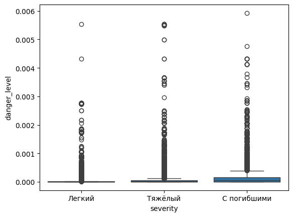

```python
sns.boxplot(x="severity", y="danger_level", data=total[total['danger_level'] < 0.006])
```

Из графика выше видно чем выше дтп, тем выше опасность дороги. Теперь посмотрим, какая тяжесть ДТП происходила чаще по адресам.

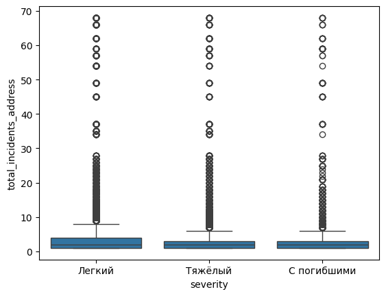

```python
sns.boxplot(x="severity", y="total_incidents_address", data=total[total['total_incidents_address'] < 80])
```

Из графика выше видно что чаще всего на количество ДТП по определенным адресам происходит ДТП легкой тяжести, остальные с одинаковой частотой как и ожидалось.

# Выделение данных для кластеризации

Следующим этапом будет подготовка к кластеризации.

Для того чтобы начать кластеризацию, мы возьмем наиболее важные признаки для составления классов уровня опасности дороги. Однако первым делом мы приведем категориальные признаки в числовой вид, чтобы использовать их в будущем:

```python
cat_col = ['light','weather','category','road_conditions','participant_categories']
encoder = LabelEncoder()

total[cat_col] = total[cat_col].apply(encoder.fit_transform)
total.head()
```

|  | id | tags | light | nearby | region | address | weather | category | datetime | severity | ... | road_conditions | participants_count | participant_categories | lat | long | total_incidents_region | total_incidents_address | severity_num | danger_level | frequency |
| --- | --- | --- | --- | --- | --- | --- | --- | --- | --- | --- | --- | --- | --- | --- | --- | --- | --- | --- | --- | --- | --- |
| 1 | 2320091 | Дорожно-транспортные происшествия, ДТП и постр... | 4 | Многоквартирные жилые дома, Внутридворовая тер... | Барнаул | г Барнаул, ул Сиреневая, 11 | 7 | 1 | 2015-09-16 13:00:00 | Легкий | ... | 1142 | 2 | 8 | 53.345833 | 83.666389 | 10375 | 1 | 3 | 9.290173e-09 | 0.000096 |
| 2 | 2321011 | Дорожно-транспортные происшествия, ДТП и постр... | 4 | Административные здания, Остановка общественно... | Барнаул | г Барнаул, ул Попова, 165 | 21 | 15 | 2017-08-25 15:30:00 | Легкий | ... | 1142 | 3 | 8 | 53.197060 | 83.396880 | 10375 | 3 | 3 | 2.787052e-08 | 0.000289 |
| 3 | 2576909 | Дорожно-транспортные происшествия | 4 | Выезд с прилегающей территории, Административн... | Барнаул | г Барнаул, ул Петра Сухова, 83 А | 21 | 16 | 2021-05-29 19:40:00 | Тяжёлый | ... | 1274 | 3 | 9 | 53.376400 | 83.714200 | 10375 | 2 | 2 | 3.716069e-08 | 0.000193 |
| 4 | 2575209 | Дорожно-транспортные происшествия | 4 | Многоквартирные жилые дома, Жилые дома индивид... | Барнаул | г Барнаул, ул Партизанская, 26 | 21 | 16 | 2021-05-25 16:40:00 | Легкий | ... | 1331 | 2 | 2 | 53.343071 | 83.794366 | 10375 | 1 | 3 | 9.290173e-09 | 0.000096 |
| 5 | 2547743 | Дорожно-транспортные происшествия | 4 | Эстакада, путепровод | Барнаул | г Барнаул, Объездная дорога в обход г. Барнаул... | 21 | 16 | 2021-02-22 13:50:00 | Тяжёлый | ... | 665 | 4 | 2 | 53.290476 | 83.708739 | 10375 | 12 | 2 | 2.229641e-07 | 0.001157 |

5 rows × 23 columns

Данные теперь в числовом виде, теперь можно выделить важные признаки для составления классов опасности дорог. Задаем в переменную data_for_models некоторые значения из total для будущий моделей кластаризации

```python
data_for_models = total[['id', 'total_incidents_address','danger_level', 'frequency']]
print(data_for_models.shape)
```

```
(67463, 4)
```

```python
data_for_models.head()
```

|  | id | total_incidents_address | danger_level | frequency |
| --- | --- | --- | --- | --- |
| 1 | 2320091 | 1 | 9.290173e-09 | 0.000096 |
| 2 | 2321011 | 3 | 2.787052e-08 | 0.000289 |
| 3 | 2576909 | 2 | 3.716069e-08 | 0.000193 |
| 4 | 2575209 | 1 | 9.290173e-09 | 0.000096 |
| 5 | 2547743 | 12 | 2.229641e-07 | 0.001157 |

# Кластеризация набора данных

Для составления локтя мы воспользуемся методом Kmeans с количеством кластеров от 1 до 10:(График локтя это специальный метод, который показывает сколько кластеров стоит использовать)

```python
wcss = []
for clusters in range(1, 11):

    model = KMeans(n_clusters=clusters, max_iter=300, n_init=10, random_state=45)
    model.fit(data_for_models.drop('id', axis=1))

    wcss.append(model.inertia_)
```

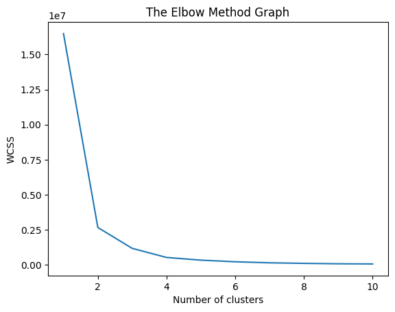

```python
plt.plot(range(1,11),wcss)
plt.title('The Elbow Method Graph')
plt.xlabel('Number of clusters')
plt.ylabel('WCSS')
plt.show()
```

На графике выше мы выделили 4 кластера, с ним и продолжим работу. Давайте инициализируем метод Kmeans с 4 кластерами и обучим его:

```python
model = KMeans(n_clusters=4, max_iter=300, n_init=10, random_state=45)
data_for_models['clusters'] = model.fit_predict(data_for_models.drop('id', axis=1))
```

Посмотрим какие классы имеют при себе наибольшее количество элементов:

```python
data_for_models.clusters.value_counts()
```

```
clusters
3    57354
0     8793
1      713
2      603
Name: count, dtype: int64
```

Однакопроверим как ситуация обстоит в уровне опасности дорог по каждому кластеров:

```python
print("Максимальный уровень опасности дороги в кластере 0:", data_for_models[data_for_models.clusters == 0]['danger_level'].max())
print("Максимальный уровень опасности дороги в кластере 1:", data_for_models[data_for_models.clusters == 1]['danger_level'].max())
print("Максимальный уровень опасности дороги в кластере 2:", data_for_models[data_for_models.clusters == 2]['danger_level'].max())
print("Максимальный уровень опасности дороги в кластере 3:", data_for_models[data_for_models.clusters == 3]['danger_level'].max())
```

```
Максимальный уровень опасности дороги в кластере 0: 0.0625
Максимальный уровень опасности дороги в кластере 1: 0.0001260574274393435
Максимальный уровень опасности дороги в кластере 2: 0.00124719249570617
Максимальный уровень опасности дороги в кластере 3: 0.03324099722991689
```

```python
data_for_graphic = data_for_models.copy()
```

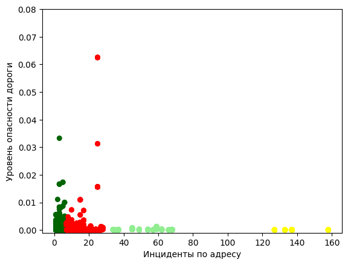

```python
colors = [ 'red', 'darkgreen', 'lightgreen', 'yellow']
data_for_graphic['color'] = data_for_graphic.clusters.map({0:colors[0], 1:colors[3], 2:colors[2], 3:colors[1]})
plt.scatter(data_for_graphic.total_incidents_address, data_for_graphic.danger_level, c=data_for_graphic.color, s=30)
plt.ylim(-0.001, 0.08)
plt.xlabel('Инциденты по адресу')
plt.ylabel('Уровень опасности дороги')
```

Данные в ужасном виде.Проверим следующий метод класстеризации - гаусовсская кластеризация. Здесь мы также воспользуемся данными, которые строили нам Kmeans и количество кластеров то же - 4:

```python
gaussian_data = data_for_models.drop('clusters', axis=1).copy()
gaussian_data.head(2)
```

|  | id | total_incidents_address | danger_level | frequency |
| --- | --- | --- | --- | --- |
| 1 | 2320091 | 1 | 9.290173e-09 | 0.000096 |
| 2 | 2321011 | 3 | 2.787052e-08 | 0.000289 |

```python
gm = GaussianMixture(n_components=4, random_state=0).fit(gaussian_data.drop('id', axis=1))
gaussian_data['clusters'] = gm.predict(gaussian_data.drop('id', axis=1))
gaussian_data['clusters'].value_counts()
```

```
clusters
0    52788
3    11179
2     2783
1      713
Name: count, dtype: int64
```

Проверим максимальные значения в каждом кластере:

```python
print("Максимальный уровень опасности дороги в кластере 0:", gaussian_data[gaussian_data.clusters == 0]['danger_level'].max())
print("Максимальный уровень опасности дороги в кластере 1:", gaussian_data[gaussian_data.clusters == 1]['danger_level'].max())
print("Максимальный уровень опасности дороги в кластере 2:", gaussian_data[gaussian_data.clusters == 2]['danger_level'].max())
print("Максимальный уровень опасности дороги в кластере 3:", gaussian_data[gaussian_data.clusters == 3]['danger_level'].max())
```

```
Максимальный уровень опасности дороги в кластере 0: 0.0007304601899196494
Максимальный уровень опасности дороги в кластере 1: 0.0001260574274393435
Максимальный уровень опасности дороги в кластере 2: 0.0014109110454178983
Максимальный уровень опасности дороги в кластере 3: 0.0625
```

Самый опасный кластер - 3, самый безопасный - 1. Данные распределены в более разбросанном виде, что немного радует, давайте теперь отобразим все на графике:

```python
gaussian_data_for_graphic = gaussian_data.copy()
```

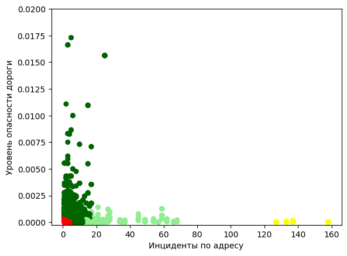

```python
colors = [ 'red', 'yellow', 'lightgreen', 'darkgreen']
gaussian_data_for_graphic['color'] = gaussian_data_for_graphic.clusters.map({0:colors[0], 1:colors[1], 2:colors[2], 3:colors[3]})
plt.scatter(gaussian_data_for_graphic.total_incidents_address,
            gaussian_data_for_graphic.danger_level,
            c=gaussian_data_for_graphic.color, s=30)
plt.ylim(-0.00025, 0.02)
plt.xlabel('Инциденты по адресу')
plt.ylabel('Уровень опасности дороги')
```

Следующим действием будет объединение данных с итоговой выборкой, но под другой переменной:

```python
total_data_clusters = total.copy()
total_data_clusters = total_data_clusters.merge(gaussian_data_for_graphic, on=['id','total_incidents_address','danger_level','frequency'])
total_data_clusters.head()
```

|  | id | tags | light | nearby | region | address | weather | category | datetime | severity | ... | participant_categories | lat | long | total_incidents_region | total_incidents_address | severity_num | danger_level | frequency | clusters | color |
| --- | --- | --- | --- | --- | --- | --- | --- | --- | --- | --- | --- | --- | --- | --- | --- | --- | --- | --- | --- | --- | --- |
| 0 | 2320091 | Дорожно-транспортные происшествия, ДТП и постр... | 4 | Многоквартирные жилые дома, Внутридворовая тер... | Барнаул | г Барнаул, ул Сиреневая, 11 | 7 | 1 | 2015-09-16 13:00:00 | Легкий | ... | 8 | 53.345833 | 83.666389 | 10375 | 1 | 3 | 9.290173e-09 | 0.000096 | 0 | red |
| 1 | 2321011 | Дорожно-транспортные происшествия, ДТП и постр... | 4 | Административные здания, Остановка общественно... | Барнаул | г Барнаул, ул Попова, 165 | 21 | 15 | 2017-08-25 15:30:00 | Легкий | ... | 8 | 53.197060 | 83.396880 | 10375 | 3 | 3 | 2.787052e-08 | 0.000289 | 0 | red |
| 2 | 2576909 | Дорожно-транспортные происшествия | 4 | Выезд с прилегающей территории, Административн... | Барнаул | г Барнаул, ул Петра Сухова, 83 А | 21 | 16 | 2021-05-29 19:40:00 | Тяжёлый | ... | 9 | 53.376400 | 83.714200 | 10375 | 2 | 2 | 3.716069e-08 | 0.000193 | 0 | red |
| 3 | 2575209 | Дорожно-транспортные происшествия | 4 | Многоквартирные жилые дома, Жилые дома индивид... | Барнаул | г Барнаул, ул Партизанская, 26 | 21 | 16 | 2021-05-25 16:40:00 | Легкий | ... | 2 | 53.343071 | 83.794366 | 10375 | 1 | 3 | 9.290173e-09 | 0.000096 | 0 | red |
| 4 | 2547743 | Дорожно-транспортные происшествия | 4 | Эстакада, путепровод | Барнаул | г Барнаул, Объездная дорога в обход г. Барнаул... | 21 | 16 | 2021-02-22 13:50:00 | Тяжёлый | ... | 2 | 53.290476 | 83.708739 | 10375 | 12 | 2 | 2.229641e-07 | 0.001157 | 3 | darkgreen |

5 rows × 25 columns

Смотрим нормально ли добавились новые столбцы

```python
total_data_clusters.info()
```

```
<class 'pandas.core.frame.DataFrame'>
RangeIndex: 67463 entries, 0 to 67462
Data columns (total 25 columns):
 #   Column                   Non-Null Count  Dtype
---  ------                   --------------  -----
 0   id                       67463 non-null  int64
 1   tags                     67463 non-null  object
 2   light                    67463 non-null  int32
 3   nearby                   67463 non-null  object
 4   region                   67463 non-null  object
 5   address                  67463 non-null  object
 6   weather                  67463 non-null  int32
 7   category                 67463 non-null  int32
 8   datetime                 67463 non-null  object
 9   severity                 67463 non-null  object
```

[output cut: 17 more lines]

```python
total_data_clusters.clusters.value_counts()
```

```
clusters
0    52788
3    11179
2     2783
1      713
Name: count, dtype: int64
```

Два столбца были добавлены по своим местам, а это значит что у нас полностью готовая таблица для обучения моделей машинного обучения. Также количество значений в кластере осталось тем же, значит копирование данных прошло успешно.

```python
total_data_clusters.to_csv("total_5_regions.csv", index=False)
```

# Разбиение данных

Копируем перемунную total_data_clusters в total_data_raz

```python
total_data_raz = total_data_clusters.copy()
```

```python
total_data_raz['region'].unique()
```

```
array(['Барнаул', 'Немецкий национальный район', 'Шипуновский район',
       'Чарышский район', 'Целинный район', 'Хабарский район',
       'Усть-Пристанский район', 'Усть-Калманский район',
       'Угловский район', 'Тюменцевский район', 'Троицкий район',
       'Третьсяковский район', 'Топчихинский район', 'Тогульский район',
       'Тальменский район', 'Табунский район', 'Шелаболихинский район',
       'Солтонский район', 'Солонешенский район', 'Советский район',
       'Суетский район', 'Славгородский район', 'Романовский район',
       'Родинский район', 'Ребрихинский район', 'Поспелихинский район',
       'Петропавловский район', 'Панкрушихинский район',
       'Павловский район', 'Зональный район', 'Новичихинский район',
       'Михайловский район', 'Мамонтовский район', 'Локтевский район',
       'Кытмановский район', 'Курьинский район', 'Кулундинский район',
       'Крутихинский район', 'Краснощековский район',
       'Красногорский район', 'Косихинский район', 'Ключевский район',
       'Каменский район', 'Калманский район', 'Змеиногорский район',
       'Залесовский район', 'Завьяловский район', 'Ельцовский район',
       'Егорьевский район', 'Волчихинский район', 'Быстроистокский район',
       'Бурлинский район', 'Благовещенский район', 'Баевский район',
       'Алтайский район', 'Алейский район', 'Смоленский район',
       'Рубцовский район', 'Первомайский район', 'Заринский район',
       'Бийский район', 'Рубцовск', 'Заринск', 'Бийск', 'Белокуриха',
       'Сибирский', 'Новоалтайск', 'Яровое', 'Бурейский район',
       'Свободненский район', 'Серышевский район', 'Белогорский район',
       'Шимановский район', 'Тындинский район', 'Зейский район',
       'Тамбовский район', 'Сковородинский район', 'Селемджинский район',
       'Ромненский район', 'Октябрьский район', 'Мазановский район',
       'Магдагачинский район', 'Константиновский район',
       'Ивановский район', '7 - Завитинский район', 'Архаринский район',
       'пгт. Углегорск', 'Благовещенск', 'Райчихинск', 'Онежский район',
       'Мезенский район', 'Каргопольский район', 'Коношский район',
       'Вельский район', 'Устьянский район', 'Няндомский район',
       'Красноборский район', 'Вилегодский район', 'Ленский район',
       'Холмогорский район', 'Пинежский район', 'Верхнетоемский район',
       'Виноградовский район', 'Шенкурский район', 'Лешуконский район',
       'Приморский район', 'Плесецкий район', 'Котласский район',
       'Новодвинск', 'ЗАТО Мирный', 'Котлас', 'Архангельск',
       'Северодвинск', 'Коряжма', 'Астрахань', 'Черноярский район',
       'Харабалинский район', 'Приволжский район', 'Наримановский район',
       'Лиманский район', 'Красноярский район', 'Камызякский район',
       'Икрянский район', 'Енотовский район', 'Володарский район',
       'Ахтубинский район', 'ЗАТО Знаменск', 'Белгород',
       'Яковлевский район', 'Шебекинский  район', 'Чернянский район',
       'Старооскольский район', 'Ровеньский район', 'Рекитянский район',
       'Прохоровский район', 'Новооскольский район',
       'Краснояружский район', 'Красногвардеский район',
       'Красненский район', 'Корочанский район', 'Ивнянский район',
       'Губкинский район', 'Грайворонский район', 'Волоконовский район',
       'Вейделевский район', 'Валуйский район', 'Борисовский район',
       'Белгородский район', 'Алексеевский район'], dtype=object)
```

Создаем train, test данные

```python
train, test = train_test_split(total_data_raz, test_size=0.7, train_size=0.3, random_state=42)
```

```python
test['region'].unique()
train['region'].unique()
len(test)
```

```
47225
```

```python
from sklearn.model_selection import train_test_split

# Разбиение на обучающую и тестовую выборки с сохранением данных по региону

# Исходные данные (X) с информацией о регионах и целевая переменная (y)
X, y = total_data_raz,total_data_raz

# Получение уникальных регионов из данных
regions = set(X['region'])

# Инициализация пустых списков для обучающих и тестовых данных
X_train, X_test, y_train, y_test = [], [], [], []

# Разделение данных по регионам
for region in regions:
    # Получение данных по текущему региону
    X_region = X[X['region'] == region]
    y_region = y[X['region'] == region]

    # Разбиение данных на обучающую и тестовую выборки
    X_region_train, X_region_test, y_region_train, y_region_test = train_test_split(X_region, y_region, test_size=0.2, random_state=42)

    # Добавление разбитых данных в общие списки
    X_train.append(X_region_train)
    X_test.append(X_region_test)
    y_train.append(y_region_train)
    y_test.append(y_region_test)

# Объединение данных по регионам обратно в единые массивы
X_train = pd.concat(X_train)
X_test = pd.concat(X_test)
y_train = pd.concat(y_train)
y_test = pd.concat(y_test)

# Проверка результатов
print("Обучающая выборка:")
print(X_train)
print(y_train)
print()
print("Тестовая выборка:")
print(X_test)
print(y_test)
```

```
Обучающая выборка:
            id                                               tags  light  \
16148  2323441                  Дорожно-транспортные происшествия      4
16116  2666438                  Дорожно-транспортные происшествия      2
16119  2732104  Дорожно-транспортные происшествия, ДТП и постр...      4
16174  2567905                  Дорожно-транспортные происшествия      4
16212  2575935                  Дорожно-транспортные происшествия      4
...        ...                                                ...    ...
15974  2308440  Дорожно-транспортные происшествия, ДТП и постр...      0
16014  2321088                  Дорожно-транспортные происшествия      4
16025  2641526  Дорожно-транспортные происшествия, ДТП и постр...      2
15968  2851624                  Дорожно-транспортные происшествия      4
16005  2318474                  Дорожно-транспортные происшествия      5

                                                  nearby              region  \
```

[output cut: 304 more lines]

```python
len(X_train['region'].unique())
```

```
149
```

```python
len(y_train['region'].unique())
```

```
149
```

```python
len(y_test['region'].unique())
```

```
149
```

```python
len(X_test['region'].unique())
```

```
149
```

Все

# Подбор наиболее коррелируемых признаков

Для составления моделей машинного обучения и их последующего обучения, необходимо выбрать те признаки, которые наиболее точно позволят предсказать класс опасности дороги а именно 'light','weather','category','dead_count','injured_count','road_conditions','participants_count' .Поэтому мы рассмотрим корреляционную матрицу признаков.

```python
features_target = total_data_clusters[['light','weather','category','dead_count','injured_count','road_conditions','participants_count']]
```

Корреляционная матрица требует, чтобы мы сразу указали признаки, которые являются интервальными - имеют огромное количество значений. Наименования данных признаков мы запишем в отдельной переменной и используем при создании матрицы:

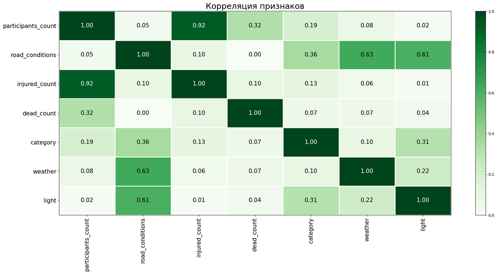

```python
interval_cols = ['dead_count','injured_count','participants_count','total_incidents_region', 'total_incidents_address', 'danger_level', 'frequency']
phik_overview = features_target.phik_matrix(interval_cols=interval_cols)

plot_correlation_matrix(phik_overview.values,
                        x_labels=phik_overview.columns,
                        y_labels=phik_overview.index,
                        vmin=0, vmax=1, color_map="Greens",
                        title="Корреляция признаков",
                        fontsize_factor=1.5,
                        figsize=(20, 10))
plt.tight_layout()
```

# Создание выборок

Первым делом мы разделим данные на обучающую и валидационную выборки с процентным соотношением 80/20:

```python
total_data_clusters.head(1)
```

|  | id | tags | light | nearby | region | address | weather | category | datetime | severity | ... | participant_categories | lat | long | total_incidents_region | total_incidents_address | severity_num | danger_level | frequency | clusters | color |
| --- | --- | --- | --- | --- | --- | --- | --- | --- | --- | --- | --- | --- | --- | --- | --- | --- | --- | --- | --- | --- | --- |
| 0 | 2320091 | Дорожно-транспортные происшествия, ДТП и постр... | 4 | Многоквартирные жилые дома, Внутридворовая тер... | Барнаул | г Барнаул, ул Сиреневая, 11 | 7 | 1 | 2015-09-16 13:00:00 | Легкий | ... | 8 | 53.345833 | 83.666389 | 10375 | 1 | 3 | 9.290173e-09 | 0.000096 | 0 | red |

1 rows × 25 columns

Задаем в переменную только нужные значения

```python
total = total_data_clusters[['danger_level', 'frequency']]
```

```python
total_clusters = total_data_clusters[['clusters']]
```

```python
most_corr_col = total#, 'total_incidents_address']#
features_train, features_valid, target_train, target_valid = train_test_split(total_clusters[most_corr_col], total_clusters['clusters'], test_size=0.20, random_state=69)
print(features_train.shape, features_valid.shape)
```

```
(53970, 1) (13493, 1)
```

Отобразим на графики размерность классов

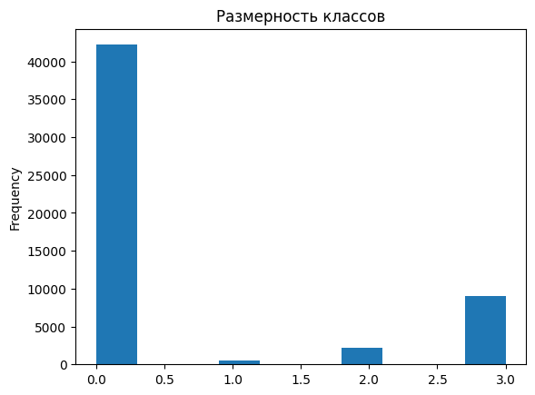

```python
target_train.plot(kind='hist', title='Размерность классов')
```

Из этого видно что классов 0 более 40000тыс штук, а классов 1.0 очень мало

# Выводы

```python
total_data_clusters.to_csv("total_ready.csv", index=False)
```